# Ipython_tutorial

[figure not shown]

# IPython Notebook Tutorial

IPython has a beautiful Notebook that lets you write and execute code, analyze data, embed content, and share reproducible work. IPython lets you easily share your code, data, plots, and explanation in one Notebook. Publishing is flexible: PDF, HTML, ipynb, dashboards, slides, and more. Code cells are based on an input and output format. For example:

```python
print "hello world"
```

```
hello world
```

This tutorial will cover:

- Introduction: installation, helpful commands, package management
- SciPy Stack: SciPy, Numpy, pandas
- Plotting: matplotlib, mpld3, pandas, maps, 3D plotting, ggplot for Python, Seaborn, ggplot2, and R
- Embedding: iframes, videos, LaTeX
- Publishing: files, widgets, dashboards, styling

# I. Introduction

There are a few ways to use an IPython Notebook. For Windows users, you'll need [`setuptools`](http://ipython.org/ipython-doc/2/install/install.html#windows). This Notebook uses Python 2; Python 3 offers exciting new opportunities for IPython.

- If you have `setuptools` or `pip` installed, you can open a terminal and type: `$ pip install ipython`.
- [Anaconda](https://store.continuum.io/cshop/anaconda/) and [Enthought](https://store.enthought.com/downloads/#default) allow you to download a desktop version of IPython Notebook.
- [coLaboratory](https://store.enthought.com/downloads/#default) allows you to run Notebooks using Google Chrome.
- [Docker containers](https://hub.docker.com/r/ipython/notebook/) let you run Notebooks.
- [Domino](http://support.dominodatalab.com/hc/en-us/articles/204856585-Jupyter-Notebooks), [Authorea](https://www.authorea.com/users/3/articles/3904/_show_article), and [Wakari](https://wakari.io/) offer web-based Notebooks.
- tmpnb launches a temporary online Notebook for individual users.
- Hosted services like [Sciencebox](https://aws.amazon.com/marketplace/pp/B00KQY1T32/ref=mkt_wir_yhatsciencebox) let users launch a prebuilt virtual machine.

Once you've installed the Notebook, you start from your terminal by calling `$ ipython notebook`. This will open a browser on a [localhost](https://en.wikipedia.org/wiki/Localhost) to the URL of your Notebooks, by default http://127.0.0.1:8888. Windows users need to open up their Command Prompt. You'll see a dashboard with all your Notebooks. You can launch your Notebooks from there. The Notebook has the advantage of looking the same when you're coding and publishing. You just have all the options to move code, run cells, change kernels, and [use Markdown](https://github.com/adam-p/markdown-here/wiki/Markdown-Cheatsheet) when you're running a NB. Here's what a Notebook looks like in action if you call it from your terminal.

[figure not shown]

## Helpful commands

IPython supports tab completion. You can type `object_name.<TAB>` to view an object’s attributes. For tips on cell magics, running Notebooks, and exploring objects, check out the [IPython docs](https://ipython.org/ipython-doc/dev/interactive/tutorial.html#introducing-ipython). IPython also has a few [helpful commands](https://ipython.org/ipython-doc/dev/interactive/tutorial.html#the-four-most-helpful-commands) like:

```python
help # introduction and overview of features
```

```
Type help() for interactive help, or help(object) for help about object.
```

```python
%quickref # opens quick reference
```

The Notebook defaults to C:\Users\USERNAME or the folder where you've run the Notebook. You can call `ipython notebook --help-all` then [change your directory](http://stackoverflow.com/questions/15680463/change-ipython-working-directory) if needed. You can also [use `%run`](http://stackoverflow.com/questions/3438531/ipython-workflow-edit-run) to run local Python scripts you've written.

IPython has [keyboard shortcuts](https://ipython.org/ipython-doc/1/interactive/notebook.html#keyboard-shortcuts). `Shift-Enter` will run a cell, `Ctrl-Enter` will run a cell in-place, `Alt-Enter` will run a cell and insert another below.

## Package management

When installing packages in IPython, you either need to install the package in your actual shell, or run the `!` prefix, e.g.:

```
!pip install packagename
```

You may want to [reload submodules](http://stackoverflow.com/questions/5364050/reloading-submodules-in-ipython) if you've edited the code in one. IPython comes with automatic reloading magic. You can reload all changed modules before executing a new line.

```
%load_ext autoreload
%autoreload 2
```

# II. SciPy Stack

## SciPy & NumPy

[`SciPy`](http://www.scipy.org/) is a Python-based ecosystem of packages for math, science, and engineering. We'll show a quick [example](https://oneau.wordpress.com/2011/02/28/simple-statistics-with-scipy/) below. `NumPy` is a package for scientific computing with tools for algebra, random number generation, integrating with databases, and managing data. NumPy functions [have been imported](http://stackoverflow.com/questions/6200910/relationship-between-scipy-and-numpy) into the SciPy namespace so users don't have to differentiate between them.

```python
import scipy as sp
import numpy as np
```

```python
s = sp.randn(100)
print len(s)
```

```
100
```

We can print the mean of our data into our Notebook. Since the returned value is a NumPy array we can find and print descriptive statistics about the random numbers we created with SciPy.

```python
print("Mean : {0:8.6f}".format(s.mean()))
```

```
Mean : 0.171686
```

[Arrays](http://www.python-course.eu/numpy.php) are the central part of NumPy and are more efficient lists of Python. The elements of a NumPy array have to be of the same type, usually float or int.

```python
x = np.array([42,47,11], int)
x = np.array([42,47,11], int)
x
```

```
array([42, 47, 11])
```

## pandas

If you have a tabular data structure, [`pandas`](http://pandas.pydata.org/pandas-docs/stable/generated/pandas.DataFrame.html) is the way to go. Dataframes are easy to make, and handle data better than Python lists or tuples. The [10 minutes to pandas](http://pandas.pydata.org/pandas-docs/stable/10min.html) guide is a good introduction and a useful exercise. So is Michael Hansen's [tutorial](http://synesthesiam.com/posts/an-introduction-to-pandas.html).

```python
import pandas as pd
```

One can create a dataframe in pandas with the handy functions in [read_csv](http://pandas.pydata.org/pandas-docs/stable/generated/pandas.read_csv.html). You can read from a URL or a local file. Here we'll make a dataframe from a matplotlib plot we'll make below with Plotly. You can append .py, .r, .m, .jl, .json, .js, .png, .pdf, .png, .svg, .embed, .xlsx, and .csv to any Plotly URL to see extensions of the figure.

```python
df = pd.read_csv("https://plot.ly/~MattSundquist/20387.csv")
```

We can [`describe`](http://pandas.pydata.org/pandas-docs/stable/generated/pandas.DataFrame.describe.html) the dataframe we've just created.

```python
df.describe() #
```

|  | line0_volts | line0_time, line1_time, line3_time | line1_volts | line2_volts | line2_time | line3_volts |
| --- | --- | --- | --- | --- | --- | --- |
| count | 200.000000 | 200.000000 | 2.000000e+02 | 20.000000 | 20.000000 | 2.000000e+02 |
| mean | 0.434498 | 0.995000 | -1.665335e-18 | 0.620175 | 0.950000 | 6.708533e-02 |
| std | 0.243705 | 0.578792 | 7.088812e-01 | 0.324605 | 0.591608 | 3.402314e-01 |
| min | 0.136695 | 0.000000 | -1.000000e+00 | 0.000000 | 0.000000 | -4.781305e-01 |
| 25% | 0.224812 | 0.497500 | -6.956525e-01 | 0.388217 | 0.475000 | -1.651344e-01 |
| 50% | 0.369728 | 0.995000 | 6.123234e-17 | 0.667501 | 0.950000 | 3.713929e-17 |
| 75% | 0.608055 | 1.492500 | 6.956525e-01 | 0.885674 | 1.425000 | 2.722606e-01 |
| max | 1.000000 | 1.990000 | 1.000000e+00 | 1.064711 | 1.900000 | 7.883040e-01 |

We can also examine how many rows we have. Calling the `columns` property gives you columns.

```python
len(df)
```

```
200
```

Calling .head() will print the first five rows and column headers by default, or we can specify a number.

```python
df.head()  # examine dataframe
```

|  | line0_volts | line0_time, line1_time, line3_time | line1_volts | line2_volts | line2_time | line3_volts |
| --- | --- | --- | --- | --- | --- | --- |
| 0 | 1.000000 | 0.00 | 0.000000 | 0.000000 | 0.0 | 0.000000 |
| 1 | 0.990050 | 0.01 | 0.062791 | 0.095310 | 0.1 | 0.062166 |
| 2 | 0.980199 | 0.02 | 0.125333 | 0.182322 | 0.2 | 0.122851 |
| 3 | 0.970446 | 0.03 | 0.187381 | 0.262364 | 0.3 | 0.181843 |
| 4 | 0.960789 | 0.04 | 0.248690 | 0.336472 | 0.4 | 0.238939 |

We can rename our columns once we've made a dataframe.

```python
df.columns = ["volts_1", "time_1", "volts_2", "volts_2",
                "time_2", "volts_4"]
```

```python
df.head(1)
```

|  | volts_1 | time_1 | volts_2 | volts_2 | time_2 | volts_4 |
| --- | --- | --- | --- | --- | --- | --- |
| 0 | 1 | 0 | 0 | 0 | 0 | 0 |

We can use pandas for statistics and to examine our rows and columns.

```python
df.volts_1.head()
```

```
0    1.000000
1    0.990050
2    0.980199
3    0.970446
4    0.960789
Name: volts_1, dtype: float64
```

```python
df.volts_1.std()
```

```
0.24370527032639763
```

Most pandas functions also work on an entire dataframe. For example, calling `std()` calculates the standard deviation for each column.

```python
df.std()
```

```
volts_1    0.243705
time_1     0.578792
volts_2    0.708881
volts_2    0.324605
time_2     0.591608
volts_4    0.340231
dtype: float64
```

# III. Plotting

## matplotlib inline

You can [use matplotlib](https://ipython.org/ipython-doc/3/notebook/notebook.html#plotting) inside your IPython Notebook by calling `%matplotlib inline`, which has the advantage of keeping your plots in one place. If you're having trouble running matplotlib, [here](http://stackoverflow.com/questions/19410042/how-to-make-ipython-notebook-matplotlib-plot-inline) are a few common solutions. `%matplotlib inline` activates the inline backend and calls images as static pngs. A new option--`%matplotlib notebook`--lets you interact with the plot in a Notebook. This works in IPython 3.x; for older IPython versions, use `%matplotlib nbagg`.

```python
%matplotlib inline
import matplotlib.pyplot as plt # side-stepping mpl backend
import matplotlib.gridspec as gridspec # subplots
```

```python
import plotly.plotly as py
from plotly.graph_objs import *
import plotly.tools as tls
```

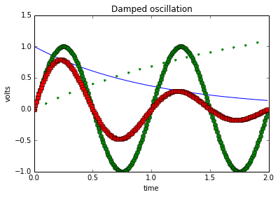

```python
fig1 = plt.figure()
# Make a legend for specific lines.
import matplotlib.pyplot as plt
import numpy as np


t1 = np.arange(0.0, 2.0, 0.1)
t2 = np.arange(0.0, 2.0, 0.01)

# note that plot returns a list of lines.  The "l1, = plot" usage
# extracts the first element of the list into l1 using tuple
# unpacking.  So l1 is a Line2D instance, not a sequence of lines
l1, = plt.plot(t2, np.exp(-t2))
l2, l3 = plt.plot(t2, np.sin(2 * np.pi * t2), '--go', t1, np.log(1 + t1), '.')
l4, = plt.plot(t2, np.exp(-t2) * np.sin(2 * np.pi * t2), 'rs-.')

plt.xlabel('time')
plt.ylabel('volts')
plt.title('Damped oscillation')

plt.show()
```

Now we can do a bit of interactive plotting. Head to the [Plotly getting started](https://plot.ly/python/) page to get a key and install the API. Calling the plot with `iplot` automaticallly generates an interactive version of the matplotlib plot inside the Notebook in an iframe. You can control the privacy with [`sharing`](https://plot.ly/python/privacy/) set to `public`, `private`, or `secret`. We'll use `strip_style` to apply the Plotly defaults. You can filter zoom by clicking and dragging and see text if you hover your mouse.

```python
py.iplot_mpl(fig1, strip_style = True, filename='ipython/mpl_example')
```

[interactive chart not shown]

## mpld3

We can use [`mpld3`](https://mpld3.github.io/index.html) to make interactive plots in the Notebook from matplotlib figures.

```python
import mpld3
mpld3.display(fig1)
```

[output not shown]

We can make [interactive plots](https://plot.ly/pandas/) from the same dataframe we made with pandas above.

```python
volts_histogram_plot = [{'x': df['volts_1'],
                 'type': 'histogram'
}]
```

```python
data_histogram = Data(volts_histogram_plot)

fig_histogram = Figure(data=data_histogram)
```

```python
py.iplot(fig_histogram, filename='pandas/volts_histogram')
```

[interactive chart not shown]

```python
volts_jitter_plot = [{'y': df['volts_1'],
                 'name': 'volts',
                 'type': 'box',
}]
```

```python
data_jitter = Data(volts_jitter_plot)

fig_jitter = Figure(data=data_jitter)
```

```python
py.iplot(fig_jitter, filename='pandas/volts_boxplot')
```

[interactive chart not shown]

For plotting directly from a dataframe, you can use [cufflinks](https://plot.ly/ipython-notebooks/cufflinks/), a pandas plotting library. Click the legend items to toggle traces on and off.

```python
import cufflinks as cf
```

```python
import pandas.io.data as web
from datetime import datetime

start = datetime(2008, 1, 1)
end = datetime(2008, 11, 28)
df_gis = web.DataReader("GIS", 'yahoo', start, end)
df_fdo = web.DataReader("FDO", 'yahoo', start, end)
df_sp = web.DataReader("GSPC", 'yahoo', start, end)

df = pd.DataFrame({'General Mills': df_gis.Open, 'Family Dollar Stores': df_fdo.Open, 'S&P 500': df_sp.Open})
df.head()

df.iplot(kind='line', fill=True,
         yTitle='Open Price', title='Top Recession Stocks',
         filename='cufflinks/stock data', world_readable=True)
```

[interactive chart not shown]

## Interactive maps

Let's make a map. We'll read in the data from another Plotly graph showing the number of electoral votes per state in the U.S. As before, if we add .csv to the end of the plot URL, we can use pandas to make a dataframe.

```python
# Learn about API authentication here: https://plot.ly/python/getting-started
# Find your api_key here: https://plot.ly/settings/api

import plotly.plotly as py

df = pd.read_csv('https://plot.ly/~Dreamshot/5718/electoral-college-votes-by-us-state/.csv')

for col in df.columns:
    df[col] = df[col].astype(str)
```

```python
df.head()
```

|  | y | Source: <a href="https://en.wikipedia.org/wiki/Electoral_College_%28United_States%29">Wikipedia</a> |
| --- | --- | --- |
| 0 | DE | 3 |
| 1 | VT | 3 |
| 2 | ND | 3 |
| 3 | SD | 3 |
| 4 | MT | 3 |

```python
df.columns = ["state", "votes"]  # change column names
```

```python
df.head(1)
```

|  | state | votes |
| --- | --- | --- |
| 0 | DE | 3 |

Now we can make an interactive D3.js graph directly from pandas. See the [pandas maps](https://plot.ly/pandas/#maps) documentation to learn more.

```python
scl = [[0.0, 'rgb(242,240,247)'],[0.2, 'rgb(218,218,235)'],[0.4, 'rgb(188,189,220)'],\
            [0.6, 'rgb(158,154,200)'],[0.8, 'rgb(117,107,177)'],[1.0, 'rgb(84,39,143)']]

df['text'] = df['state']

data = [dict(
    type='choropleth',
    colorscale = scl,
    autocolorscale = False,
    locations = df['state'],
    z = df['votes'].astype(float),
    locationmode = 'USA-states',
    text = df['text'],
    hoverinfo = 'location+z',
    marker = dict(
        line = dict (
            color = 'rgb(255,255,255)',
            width = 2
        )
    ),
    colorbar = dict(
        title = "Votes"
    )
)]

layout = dict(
    title = '2016 Electoral College Votes<br>(Hover for breakdown)',
    geo = dict(
        scope='usa',
        projection=dict( type='albers usa' ),
        showlakes = True,
        lakecolor = 'rgb(255, 255, 255)'
    )
)

fig = dict(data=data, layout=layout)

py.iplot(fig, validate=False, filename='d3-electoral-map')
```

[interactive chart not shown]

## 3D Plotting

Using Numpy and Plotly, we can make interactive [3D plots](https://plot.ly/python/#3d) in the Notebook as well.

```python
import plotly.plotly as py
from plotly.graph_objs import *

import numpy as np

s = np.linspace(0, 2 * np.pi, 240)
t = np.linspace(0, np.pi, 240)
tGrid, sGrid = np.meshgrid(s, t)

r = 2 + np.sin(7 * sGrid + 5 * tGrid)  # r = 2 + sin(7s+5t)
x = r * np.cos(sGrid) * np.sin(tGrid)  # x = r*cos(s)*sin(t)
y = r * np.sin(sGrid) * np.sin(tGrid)  # y = r*sin(s)*sin(t)
z = r * np.cos(tGrid)                  # z = r*cos(t)

surface = Surface(x=x, y=y, z=z)
data = Data([surface])

layout = Layout(
    title='Parametric Plot',
    scene=Scene(
        xaxis=XAxis(
            gridcolor='rgb(255, 255, 255)',
            zerolinecolor='rgb(255, 255, 255)',
            showbackground=True,
            backgroundcolor='rgb(230, 230,230)'
        ),
        yaxis=YAxis(
            gridcolor='rgb(255, 255, 255)',
            zerolinecolor='rgb(255, 255, 255)',
            showbackground=True,
            backgroundcolor='rgb(230, 230,230)'
        ),
        zaxis=ZAxis(
            gridcolor='rgb(255, 255, 255)',
            zerolinecolor='rgb(255, 255, 255)',
            showbackground=True,
            backgroundcolor='rgb(230, 230,230)'
        )
    )
)

fig = Figure(data=data, layout=layout)
py.iplot(fig, filename='Parametric_plot')
```

[interactive chart not shown]

## 3D GIF

Note the possible interactions.

[figure not shown]

# ggplot for Python

[`ggplot for Python`](https://github.com/yhat/ggplot) ports over ggplot2 syntax from R for Python users. The library has a tight integration with dataframes. We can similarly turn ggplot figures into Plotly graphs.

```python
from ggplot import *
```

```python
plot = ggplot(aes(x='date', y='beef'), data=meat) + \
    geom_line()
```

```python
fig = plot.draw()
py.iplot_mpl(fig, filename='ipython/ggplot_plot')
```

[interactive chart not shown]

## Seaborn

[`Seaborn`](http://stanford.edu/~mwaskom/software/seaborn/index.html) is focused on statistical plotting and plot types. Here we show how you can [combine plot types](http://stanford.edu/~mwaskom/software/seaborn/tutorial/distributions.html#basic-visualization-with-histograms)

```python
from numpy.random import randn
from scipy import stats
import matplotlib as mpl
import seaborn as sns
```

```python
fig16 = plt.figure()

sns.set_palette("hls")
mpl.rc("figure", figsize=(8, 4))
data = randn(200)
sns.distplot(data);

py.iplot_mpl(fig16, strip_style = True)
```

[interactive chart not shown]

# Rmagic

`Rmagic` lets us run R in our Notebook and [embed ggplot2 plots](http://stackoverflow.com/questions/17414349/plot-size-using-ggplot2-in-ipython-notebook-via-rmagic). You can execute code in R, and pull some of the results back into the Python namespace. The return value is determined when [`rpy2`](http://rpy.sourceforge.net/) returns the result of evaluating the final line. Multiple R lines can be executed by joining them with semicolons.

```python
%load_ext rpy2.ipython
```

```python
%R X=c(1,4,5,7); sd(X); mean(X)
```

```
<FloatVector - Python:0x10cc9bef0 / R:0x7fa56fc5ef48>
[4.250000]
```

[output not shown]

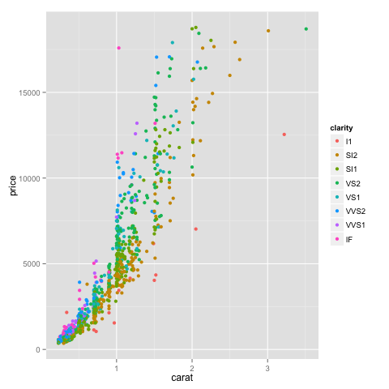

```python
%%R
library(ggplot2)
dsamp <- diamonds[sample(nrow(diamonds), 1000), ]
qplot(carat, price, data=dsamp, colour=clarity)
```

# IV. Embedding

The Notebook allows us to [embed iframes](http://ipython.org/ipython-doc/2/api/generated/IPython.lib.display.html). For example, from YouTube.

```python
from IPython.display import YouTubeVideo
```

```python
YouTubeVideo("p86BPM1GV8M")
```

[video not shown]

We can embed graphs. The plotly [ggplot2 figure](https://plot.ly/ggplot2/) converter lets us make the plot above into an interactive plot. Then you can call the plot in the NB.

```python
tls.embed('https://plot.ly/~MattSundquist/20391/price-vs-carat/')
```

[interactive chart not shown]

## Embedding LaTeX

We can embed LaTeX inside a Notebook by putting a `$$` around our math, then run the cell as a Markdown cell. For example, the cell below is `$$c = \sqrt{a^2 + b^2}$$`, but the Notebook renders the expression.

$$c = \sqrt{a^2 + b^2}$$

Or, you can display output from Python, as seen [here](http://stackoverflow.com/questions/13208286/how-to-write-latex-in-ipython-notebook).

```python
from IPython.display import display, Math, Latex
display(Math(r'F(k) = \int_{-\infty}^{\infty} f(x) e^{2\pi i k} dx'))
```

$$F(k) = \int_{-\infty}^{\infty} f(x) e^{2\pi i k} dx$$

# V. Publishing

We can export the Notebook as an HTML, PDF, .py, .ipynb, Markdown, and reST file. You can also turn your NB [into a slideshow](http://ipython.org/ipython-doc/2/notebook/nbconvert.html). For publishing IPython Notebooks directly to GitHub pages, you can use publisher. You can publish Notebooks on GitHub, and they will be generated as a Notebook on [nbviewer.ipython.org](http://nbviewer.ipython.org/). More advanced users can consider [using git for version control](http://stackoverflow.com/questions/18734739/using-ipython-notebooks-under-version-control).

[figure not shown]

## IPython widgets

[IPython widgets](http://moderndata.plot.ly/widgets-in-ipython-notebook-and-plotly/) allow you to add sliders, widgets, search boxes, and more to your Notebook. See the [widget docs](https://ipython.org/ipython-doc/3/api/generated/IPython.html.widgets.interaction.html) for more information. For others to be able to access your work, they'll need IPython. Or, you can use a cloud-based NB option so others can run your work.

[figure not shown]

## Publishing Dash Apps

For users looking to ship and productionize Python apps, dash is an assemblage of Flask, Socketio, Jinja, Plotly and boiler plate CSS and JS for easily creating data visualization web-apps with your Python data analysis backend.

[figure not shown]

## Publishing dashboards

Users publishing interactive graphs can also use [dashboards.ly](http://dashboards.ly/) to arrange a plot with a drag and drop interface. These dashboards can be published, embedded, and shared.

[figure not shown]

## IPython gallery

For more IPython tutorials, see the [IPython gallery](https://plot.ly/ipython-notebooks/).

[figure not shown]

At the end of a Notebook, we can [style a plot](http://moderndata.plot.ly/custom-styling-for-ipython-notebooks-with-3-lines-of-code/) with these three lines of code.

```python
from IPython.core.display import HTML
import urllib2
HTML(urllib2.urlopen('http://bit.ly/1Bf5Hft').read())
```